# Scenario analysis for the transmission of COVID-19 in Georgia

March 17, 2020

## Introduction

The epidemiology of COVID-19 in the United States is poorly understood. To better understand the potential range of epidemic outcomes in the state of Georgia, we developed a model based on data from Hubei Province, China calibrated to regionally specific conditions in Georgia and observations of the number of reported cases in Georgia in early March.

## Data

At the time of this report, Georgia is reporting 177 cases.

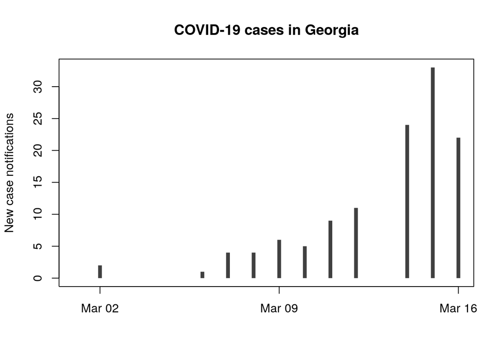

## Scenario analysis

Simulation results are illustrated in the following figures. Note the different y-axes.

### Panel analysis

A panel of scenarios is summarized as the range in total number of cases four weeks from the present time (over 25 different simulations). For planning purposes it might be assumed that case fatalities will be approximately 1% of the total number of cases. The scenario considered most plausible is highlighted in red. The following figures examine some specific scenarios in more detail.

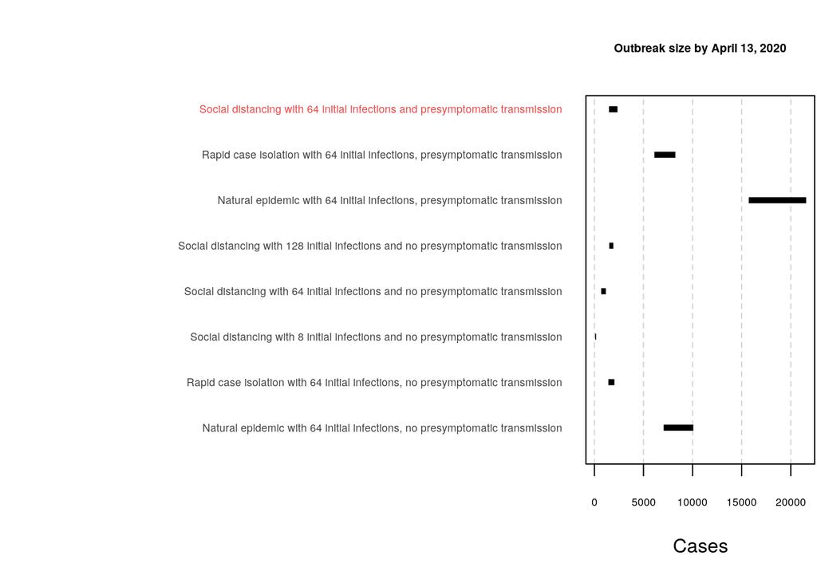

### Natural epidemic

For benchmarking, we examine a natural epidemic with presymptomatic transmission that is allowed to proceed without intervention, initiated with 64 infected persons on March 1. It is highly desirable to avoid this scenario.

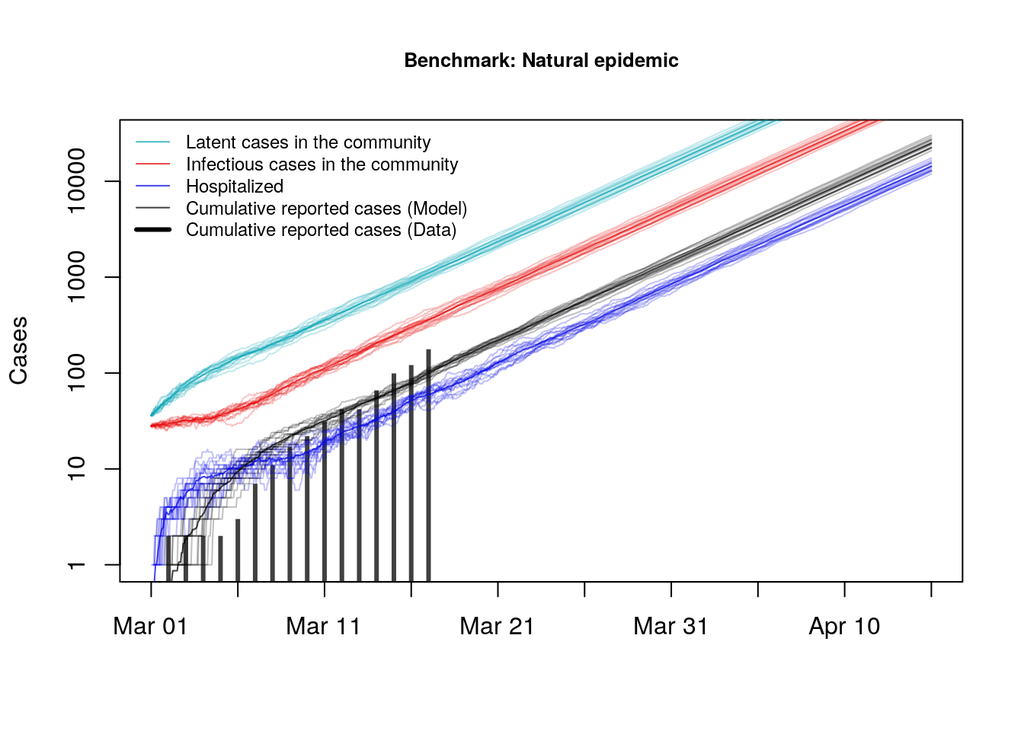

### Baseline

A baseline scenario assumes rapid case identification, but no other interventions. This scenario is initiated at the intermediate assumption of 64 infected persons on March 1. It is highly desirable to avoid this scenario.

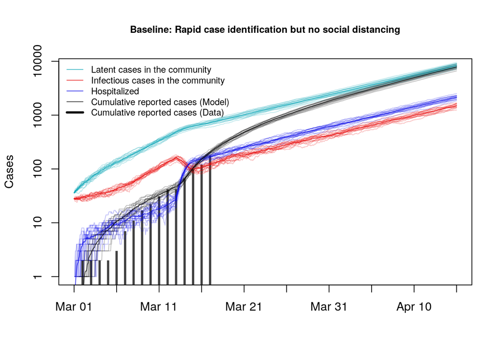

### Interventions

Here we investigate three scenarios corresponding to an inital infectious population of 8, 64, or 128 cases on March 1, approximately one day of presymptomatic transmission, and social distancing interventions begun on March 12. It would appear that the total case reports of 42 by March 13 are most consistent with the intermediate scenario of 64 initial cases.

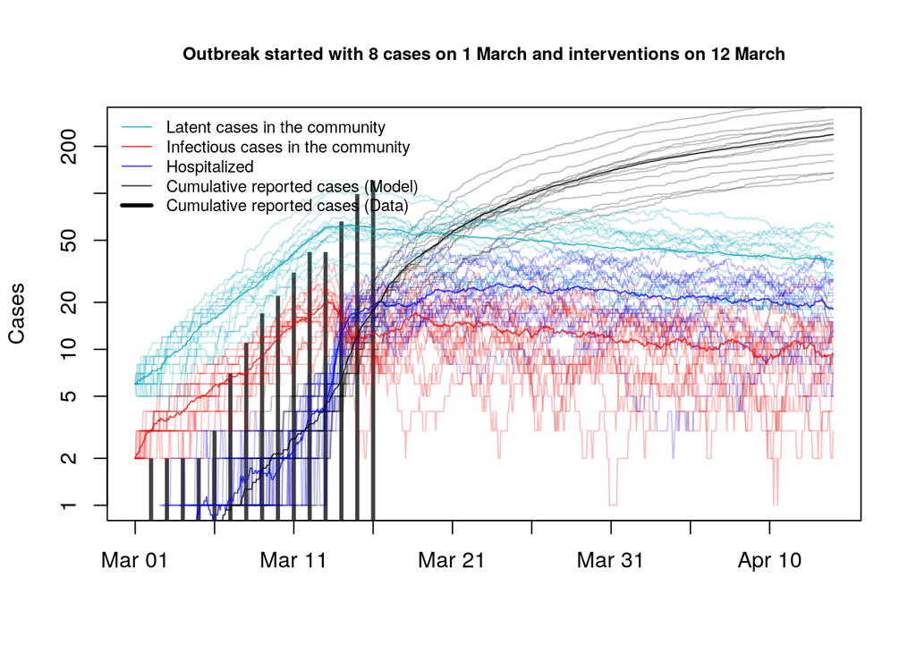

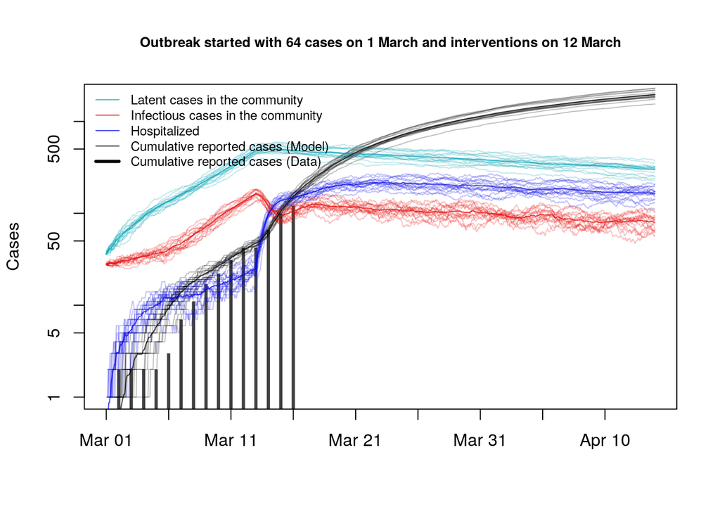

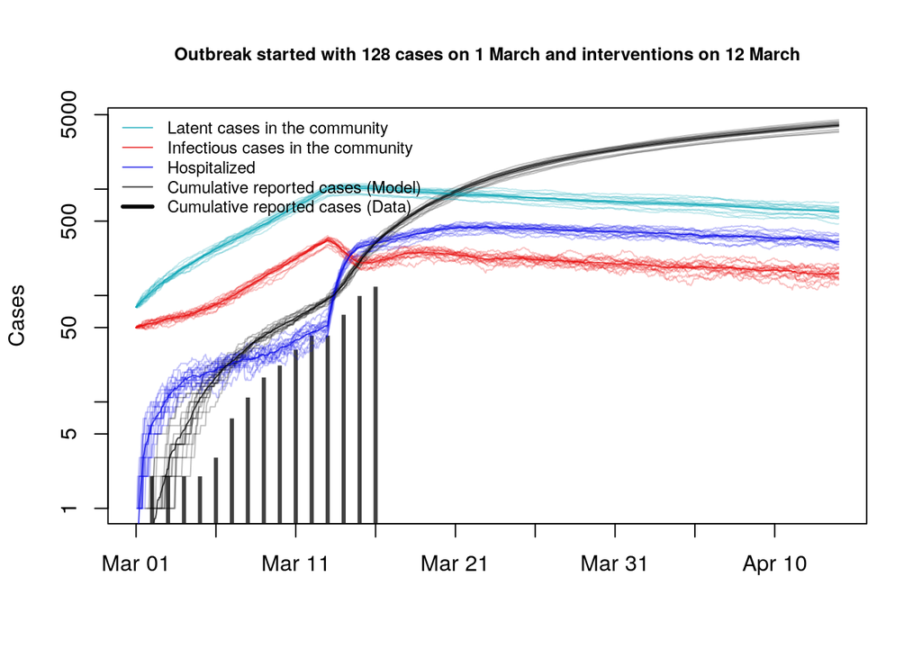

## Model details

Key features of this model include:

1. Stochastic transmission process
2. Realistic wait time distributions
3. Time varying rates of case detection, isolation, and case notification

This model was parameterized using clinical outcome reports from the epidemic in Hubei province, China and further calibrated by fitting to case notification data. The COVID-19 epidemic is changing rapidly and information that was used in the construction of this model may be incomplete or contain errors. Accordingly, these results are preliminary, provisional, and subject to change. These results have not been peer-reviewed, but have been prepared to a professional standard with the intention of providing useful interpretation of a rapidly developing event.

### Assumptions

Transmissibility of the virus is based on estimates from transmission in Hubei ($\beta_0 = 0.6584$). The model can be optionally parameterized to allow or disallow presymptomatic transmission[^1] in the last day of the latent period. Given widespread awareness about COVID-19, it is assumed that case isolation will be relatively rapid and effective and that the primary impact of interventions will be to reduce transmissibility ($\beta$). Transmission is modeled according to pre-intervention and post-intervention conditions. The assumed date of intervention is March 12, the day the first case fatality was reported (increasing public awareness), Emory University and the University System of Georgia announced the suspension of classes, and numerous school districts announced closures. We assume a natural symptomatic infectious period prior to March 12 and a symptomatic infectious period averaging 1.5 days from symptom onset to isolation after that. Interestingly, this isolation rate yields an effective reproduction number right around 1. We assume that, on average, case notification takes three days due to the lack of testing kits and turnaround time and that all cases are eventually detected.

Prior to implementation, the effectiveness of interventions is impossible to quantify precisely. Studies of previous epidemics have quantified the impact of a variety of social distancing measures. For seasonal influenza, school closure due to holidays (which is presumably not accompanied by other social and hygienic responses) reduced the basic reproduction number from 1.7 to 1.4 (a reduction of 18%).[^2] A nationwwide elementary school strikes in Israel in 2000 reduced influenza transmission by 14.6%.[^3] Much more severe social distancing measures taken in Sydney, Australia during the 1918 influenza pandemic reduced the effective reproduction number by 38%.[^4] Finally, preliminary estimates of the effectiveness of the Chinese “lockdown” suggest that this highly intensive social distancing reduced the effective reproduction number from 2.2 to 1.58 (a reduction of 28%)[^5], from 4.65 to 1.8 (a reduction of 61.2%)[^6], or from 2.35 to 1.05 (a reduction of 55%)[^7]. Our model assumes interventions taken in Georgia around March 12 reduce transmission by 50%.

### Initialization

The model is created for a population of 10.6 million people, approximately the population size of Georgia, which is similar to the city of Wuhan, China. Transmission is simulated forward from March 1.

It is difficult to know how to initialize the model (how many imported cases initiated local transmission in the state) since the first cases in Georgia were identified through passive case finding and the availability of tests has been limited. Since numerous, presumptively unlinked cases were identified in the first week of March and the first death occurred on 12 March, we attempt to bound the initial number of cases as follows.

1. UPPER BOUND: From date of first death of 12 March, a presumptive case fatality rate between 1% and 4%, and average time to death of 18 days, one might conclude that 25 to 100 persons were infected in Georgia by 23 February. We consider this to be approximately 128 cases on March 1. (However, this case was reported to display relevant comorbidities prior to fatality and died two days after hospitalization, suggesting a faster than average disease progression.)
2. INTERMEDIATE: Within the first week of March, seven cases were confirmed in Georgia. We estimated a case detection rate of 11% in Wuhan when it was in a similar stage of outbreak. If we correct the number of known cases by this factor, we conclude that there were $7/0.11 \approx 64$ cases in Georgia in the first week of March.
3. LOWER BOUND: As of 13 March, 42 cases are known. If these are the majority of cases (i.e. case detection and notification is actually really good) and represent two infection generations, then there were perhaps $\frac{42}{R_0^2} = \frac{42}{2.3^2} \approx 8$ persons infected in Georgia on March 1. This seems unlikely.
[^1]: [Rong et al. 2020](https://wwwnc.cdc.gov/eid/article/26/5/20-0198_article?deliveryName=DM20712), [Du et al. 2020](https://www.medrxiv.org/content/10.1101/2020.02.19.20025452v3)
[^2]: [Cauchemez et al. 2008](https://www.nature.com/articles/nature06732)
[^3]: Heymann et al. 2009
[^4]: [Caley et al. 2007](https://royalsocietypublishing.org/doi/full/10.1098/rsif.2007.1197?casa_token=eQnQR8Pr0x4AAAAA%3AGrDc1y8Xl8cbUt8eiNJNmKzLzre_1ZSw8U07JFyQaiQDuzGqpGY--pK-OU9ZwD3_yCK3aRGO2v2R)
[^5]: [Zhang et al. 2020](https://www.medrxiv.org/content/10.1101/2020.03.04.20031187v1.full.pdf+html)
[^6]: Ku et al. 2020
[^7]: Kucharski et al. 2020